[Edit on GitHub](https://github.com/DanielVandH/DelaunayTriangulation.jl/tree/main/docs/src/literate_tutorials/clipped.jl)

# Clipped Voronoi Tessellations

## Clipping to the Convex Hull

One issue that may arise when dealing with Voronoi tessellations is the presence of unbounded polygons occurring on the boundary. One way to deal with this is to clip polygons to the convex hull of the tessellation. (Arbitrary clipping boundaries are on the to-do list, but they are not yet implemented - see [Issue #48](https://github.com/DanielVandH/DelaunayTriangulation.jl/issues/48).)

In the example below, we clip the tessellation to the convex hull of the point set by setting the second argument of `voronoi` to `true`.

```julia
using DelaunayTriangulation
using CairoMakie
using StableRNGs
using ReferenceTests #src

rng = StableRNG(123)
points = randn(rng, 2, 50)
tri = triangulate(points; rng)
vorn = voronoi(tri)
```

```
Voronoi Tessellation.
    Number of generators: 50
    Number of polygon vertices: 92
    Number of polygons: 50
```

```julia
clipped_vorn = voronoi(tri, true)
```

```
Voronoi Tessellation.
    Number of generators: 50
    Number of polygon vertices: 119
    Number of polygons: 50
```

Note that the clipping has put more polygon vertices in. We compare the clipped tessellations below.

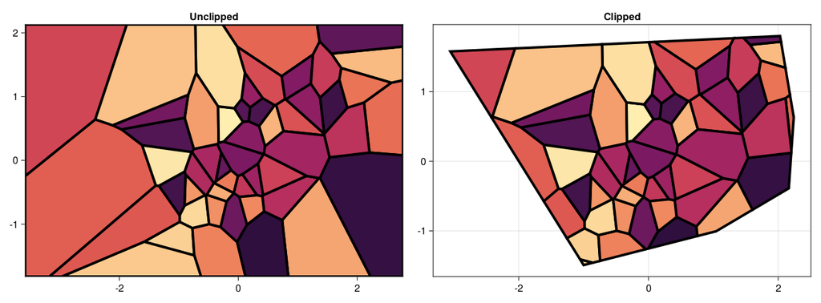

```julia
fig = Figure()
ax1 = Axis(fig[1, 1], title="Unclipped", width=600, height=400)
ax2 = Axis(fig[1, 2], title="Clipped", width=600, height=400)
voronoiplot!(ax1, vorn, show_generators=false, colormap=:matter, strokewidth=4)
voronoiplot!(ax2, clipped_vorn, show_generators=false, colormap=:matter, strokewidth=4)
resize_to_layout!(fig)
fig
```

As you can see, the unbounded polygons, and any polygons that included points outside of the convex hull, have now been clipped to the convex hull.

## Just the code

An uncommented version of this example is given below. You can view the source code for this file [here](https://github.com/DanielVandH/DelaunayTriangulation.jl/tree/new-docs/docs/src/literate_tutorials/clipped.jl).

```julia
using DelaunayTriangulation
using CairoMakie
using StableRNGs
using ReferenceTests #src

rng = StableRNG(123)
points = randn(rng, 2, 50)
tri = triangulate(points; rng)
vorn = voronoi(tri)

clipped_vorn = voronoi(tri, true)

fig = Figure()
ax1 = Axis(fig[1, 1], title="Unclipped", width=600, height=400)
ax2 = Axis(fig[1, 2], title="Clipped", width=600, height=400)
voronoiplot!(ax1, vorn, show_generators=false, colormap=:matter, strokewidth=4)
voronoiplot!(ax2, clipped_vorn, show_generators=false, colormap=:matter, strokewidth=4)
resize_to_layout!(fig)
fig
```

*This page was generated using Literate.jl.*